# Fragilidad bancaria, riesgo de cola y spread soberano

Panel Bloomberg (base final, EMBI Global Diversified) — batería de 24 regresiones y robustez

Mauricio Valenzuela

2026-09-05

# 1 Objetivo

Batería de regresiones del Capítulo 2 de la tesis sobre la **base final ancla en Bloomberg** — `bbg/Panel_bloomberg.csv` —, 13-14 economías emergentes con EMBI Global Diversified, JLoss (fragilidad bancaria, Merton/KMV + punto de silla) y GaR (cuantil 5 % de crecimiento, panel cuantílico). Corea del Sur, Bulgaria y Hungría quedan fuera del panel: en las tres `JLoss` no es una medida sistémica válida a nivel país (bancos cotizados insuficientes).

Este documento reemplaza la versión anterior (base regulatoria `Panel_extended_15paises.csv`, 11 países, sin EMBI Global Diversified ni controles domésticos) — esa base quedó superada por la reconstrucción Bloomberg de la tesis y no debe citarse en la defensa.

El parámetro de interés es θ, la interacción `JLoss × GaR`. El esqueleto empírico es la **batería de 24 especificaciones** (4 modelos × 3 estructuras de efectos fijos × 2 muestras, al modo de Chari et al. 2024) que es la Tabla 2.3 de la tesis; el resto del documento es diagnóstico y robustez sobre esa misma batería.

```r
library(plm)
library(lmtest)
library(sandwich)
library(modelsummary)
library(ggplot2)
library(dplyr)
library(tidyr)
library(kableExtra)

BASE_FILE <- "bbg/Panel_bloomberg.csv"   # base final: panel único Bloomberg
CTRLS <- c("debt_gdp", "fisc_bal", "res_gdp", "ca_gdp", "infl_yoy", "reer")
CRISIS_Q <- c("2008Q4","2009Q1","2009Q2","2009Q3","2009Q4",
              "2020Q1","2020Q2","2020Q3","2020Q4","2021Q1","2021Q2","2021Q3","2021Q4")
NUCLEO_EXCL <- c("poland", "india")   # mercados de deuda local profundos, sin bucle banca-soberano

prep <- function(path) {
  d <- read.csv(path, stringsAsFactors = FALSE)
  d$year <- as.integer(substr(d$quarter, 1, 4))
  d$q    <- as.integer(substr(d$quarter, 6, 6))
  d$tnum <- d$year + (d$q - 1) / 4
  d <- d[order(d$country, d$tnum), ]
  d$GaR_pp <- d$GaR * 100
  d$sin_crisis <- !(d$quarter %in% CRISIS_Q)
  d$sin_covid  <- !(d$quarter %in% CRISIS_Q[grepl("^202[01]", CRISIS_Q)])
  d$sin_gfc    <- !(d$quarter %in% CRISIS_Q[grepl("^200[89]", CRISIS_Q)])
  d
}

# Muestra de estimacion: EMBI + JLoss + GaR disponibles simultaneamente. JLoss/GaR se
# centran DENTRO de cada muestra que se estima (igual que p8_bateria_regresiones.py) --
# invariante para theta, pero necesario para que los coeficientes de nivel coincidan.
centrar <- function(df) {
  df$JLoss_c <- df$JLoss - mean(df$JLoss)
  df$GaR_c   <- df$GaR_pp - mean(df$GaR_pp)
  df$Int     <- df$JLoss_c * df$GaR_c
  df
}

raw <- prep(BASE_FILE)
est <- subset(raw, !is.na(EMBI_bps) & !is.na(JLoss) & !is.na(GaR))
est$country <- factor(est$country)

dat <- centrar(est)
pan <- pdata.frame(dat, index = c("country", "tnum"))
DK  <- function(m) vcovSCC(m, type = "HC1", maxlag = NULL)

cat("Base:", BASE_FILE, "| países:", length(unique(dat$country)),
    "| obs:", nrow(dat), "| rango:", min(dat$quarter), "-", max(dat$quarter), "\n")
```

```
## Base: bbg/Panel_bloomberg.csv | países: 13 | obs: 721 | rango: 2004Q1 - 2026Q1
```

# 2 Cobertura del panel

```r
cov <- dat %>%
  group_by(country) %>%
  summarise(n = n(), con_CDS = sum(!is.na(CDS_bps)), desde = min(quarter), hasta = max(quarter),
            JLoss_mediana = round(median(JLoss), 2), .groups = "drop") %>%
  arrange(desc(n))
kable(cov, caption = "Cobertura por país (panel desbalanceado; ventanas distintas)") %>%
  kable_styling(full_width = FALSE, font_size = 12)
```

Cobertura por país (panel desbalanceado; ventanas distintas)

| country | n | con_CDS | desde | hasta | JLoss_mediana |
| --- | --- | --- | --- | --- | --- |
| poland | 89 | 14 | 2004Q1 | 2026Q1 | 2.64 |
| china | 79 | 79 | 2006Q3 | 2026Q1 | 3.79 |
| mexico | 77 | 77 | 2006Q4 | 2025Q4 | 2.38 |
| brazil | 75 | 75 | 2007Q3 | 2026Q1 | 4.01 |
| chile | 75 | 75 | 2007Q3 | 2026Q1 | 2.21 |
| colombia | 70 | 70 | 2008Q4 | 2026Q1 | 2.36 |
| peru | 66 | 66 | 2009Q4 | 2026Q1 | 2.18 |
| turkey | 63 | 63 | 2010Q3 | 2026Q1 | 6.04 |
| india | 54 | 0 | 2012Q4 | 2026Q1 | 7.45 |
| malaysia | 40 | 40 | 2016Q2 | 2026Q1 | 2.19 |
| indonesia | 11 | 11 | 2023Q3 | 2026Q1 | 2.27 |
| philippines | 11 | 11 | 2023Q3 | 2026Q1 | 2.86 |
| southafrica | 11 | 11 | 2023Q3 | 2026Q1 | 2.38 |

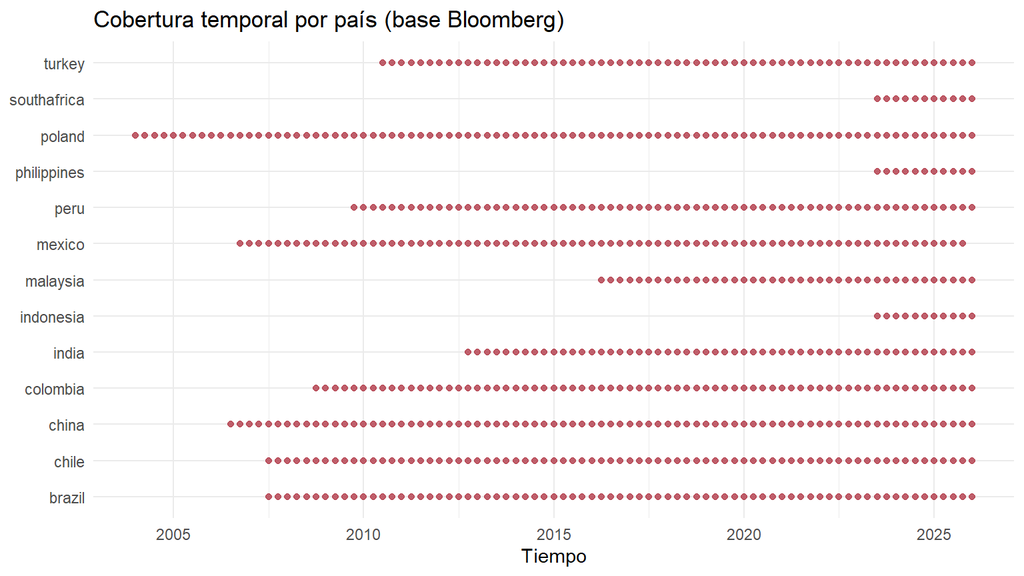

```r
ggplot(dat, aes(x = tnum, y = country)) +
  geom_point(size = 1.5, alpha = .8, color = "#b23a48") +
  labs(x = "Tiempo", y = NULL, title = "Cobertura temporal por país (base Bloomberg)") +
  theme_minimal(base_size = 11)
```

# 3 La batería de especificaciones (Tabla 2.3 de la tesis)

Cuatro modelos anidados (`JLoss` solo; `GaR` solo; ambos; ambos + interacción) × tres estructuras de efectos fijos (tiempo; país; país+tiempo) × dos muestras (completa; sin trimestres de crisis financiera aguda — GFC 2008Q4-2009Q4 y pandemia 2020Q1-2021Q4). Sin controles domésticos: mide el mecanismo “desnudo”. Errores de Driscoll-Kraay.

```r
modelos <- list(
  M1 = EMBI_bps ~ JLoss_c,
  M2 = EMBI_bps ~ GaR_c,
  M3 = EMBI_bps ~ JLoss_c + GaR_c,
  M4 = EMBI_bps ~ JLoss_c + GaR_c + Int
)
efectos <- c(tiempo = "time", país = "individual", "país+tiempo" = "twoways")

d_completa   <- pan
d_sin_crisis <- pdata.frame(centrar(subset(est, sin_crisis)), index = c("country", "tnum"))
muestras <- list(completa = d_completa, "sin crisis" = d_sin_crisis)

run_dk <- function(data, formula, effect) {
  m  <- plm(formula, data = data, model = "within", effect = effect)
  ct <- tryCatch(coeftest(m, vcov = DK(m)),
                  error = function(e) coeftest(m, vcov = vcovHC(m, method = "arellano")))
  list(model = m, test = ct, N = nobs(m),
       R2w = unname(summary(m)$r.squared["rsq"]))
}

estrella <- function(p) ifelse(p < 0.01, "***", ifelse(p < 0.05, "**", ifelse(p < 0.10, "*", "")))

filas <- list()
modelos_M4 <- list()   # para modelsummary, solo M4 (la especificación completa) x 3 FE x 2 muestras
for (sname in names(muestras)) {
  for (ename in names(efectos)) {
    for (mname in names(modelos)) {
      r <- tryCatch(run_dk(muestras[[sname]], modelos[[mname]], efectos[[ename]]), error = function(e) NULL)
      if (is.null(r)) next
      ct <- r$test
      colt <- intersect(c("t value", "z value"), colnames(ct))[1]
      fila <- data.frame(muestra = sname, modelo = mname, efectos_fijos = ename, N = r$N, R2w = round(r$R2w, 2))
      for (rn in rownames(ct)) {
        fila[[paste0(rn, "_coef")]] <- sprintf("%+.2f%s", ct[rn, "Estimate"], estrella(ct[rn, 4]))
        fila[[paste0(rn, "_t")]]    <- round(ct[rn, colt], 2)
      }
      filas[[length(filas) + 1]] <- fila
      if (mname == "M4") modelos_M4[[paste(sname, ename)]] <- r$model
    }
  }
}
bateria <- do.call(rbind, lapply(filas, function(f) {
  cols <- c("muestra","modelo","efectos_fijos","N","R2w",
            "JLoss_c_coef","JLoss_c_t","GaR_c_coef","GaR_c_t","Int_coef","Int_t")
  for (cc in cols) if (is.null(f[[cc]])) f[[cc]] <- NA
  f[cols]
}))
kable(bateria, row.names = FALSE,
      col.names = c("Muestra","Modelo","Efectos fijos","N","R²w","JLoss","t","GaR","t","JLoss×GaR","t"),
      caption = "Tabla 2.3 — batería completa (4 modelos × 3 FE × 2 muestras)") %>%
  kable_styling(full_width = FALSE, font_size = 11) %>%
  pack_rows(index = table(bateria$muestra)[unique(bateria$muestra)])
```

Tabla 2.3 — batería completa (4 modelos × 3 FE × 2 muestras)

| Muestra | Modelo | Efectos fijos | N | R²w | JLoss | t | GaR | t | JLoss×GaR | t |
| --- | --- | --- | --- | --- | --- | --- | --- | --- | --- | --- |
| **completa** |  |  |  |  |  |  |  |  |  |  |
| completa | M1 | tiempo | 721 | 0.10 | +7.41*** | 5.05 | NA | NA | NA | NA |
| completa | M2 | tiempo | 721 | 0.05 | NA | NA | -8.14*** | -3.25 | NA | NA |
| completa | M3 | tiempo | 721 | 0.19 | +8.63*** | 6.48 | -10.51*** | -3.97 | NA | NA |
| completa | M4 | tiempo | 721 | 0.19 | +8.62*** | 6.54 | -10.43*** | -4.07 | -0.16 | -0.35 |
| completa | M1 | país | 721 | 0.21 | +8.12*** | 6.51 | NA | NA | NA | NA |
| completa | M2 | país | 721 | 0.18 | NA | NA | -9.60*** | -5.49 | NA | NA |
| completa | M3 | país | 721 | 0.27 | +5.98*** | 5.13 | -6.42*** | -4.11 | NA | NA |
| completa | M4 | país | 721 | 0.28 | +6.04*** | 5.37 | -5.93*** | -3.72 | -0.21 | -0.89 |
| completa | M1 | país+tiempo | 721 | 0.09 | +4.99*** | 4.44 | NA | NA | NA | NA |
| completa | M2 | país+tiempo | 721 | 0.03 | NA | NA | -6.18** | -2.09 | NA | NA |
| completa | M3 | país+tiempo | 721 | 0.11 | +4.59*** | 4.33 | -4.28 | -1.52 | NA | NA |
| completa | M4 | país+tiempo | 721 | 0.11 | +4.61*** | 4.60 | -4.09 | -1.49 | -0.18 | -0.73 |
| **sin crisis** |  |  |  |  |  |  |  |  |  |  |
| sin crisis | M1 | tiempo | 610 | 0.08 | +6.70*** | 3.76 | NA | NA | NA | NA |
| sin crisis | M2 | tiempo | 610 | 0.07 | NA | NA | -9.14*** | -3.74 | NA | NA |
| sin crisis | M3 | tiempo | 610 | 0.18 | +8.19*** | 4.90 | -11.41*** | -4.11 | NA | NA |
| sin crisis | M4 | tiempo | 610 | 0.22 | +8.40*** | 5.27 | -10.90*** | -4.40 | -1.73*** | -4.58 |
| sin crisis | M1 | país | 610 | 0.15 | +7.01*** | 5.51 | NA | NA | NA | NA |
| sin crisis | M2 | país | 610 | 0.14 | NA | NA | -10.37*** | -4.13 | NA | NA |
| sin crisis | M3 | país | 610 | 0.20 | +5.10*** | 4.04 | -7.29*** | -3.05 | NA | NA |
| sin crisis | M4 | país | 610 | 0.24 | +5.45*** | 4.70 | -6.75*** | -2.94 | -1.16*** | -4.25 |
| sin crisis | M1 | país+tiempo | 610 | 0.07 | +4.62*** | 3.47 | NA | NA | NA | NA |
| sin crisis | M2 | país+tiempo | 610 | 0.07 | NA | NA | -9.38*** | -3.51 | NA | NA |
| sin crisis | M3 | país+tiempo | 610 | 0.12 | +3.86*** | 3.36 | -7.59*** | -3.12 | NA | NA |
| sin crisis | M4 | país+tiempo | 610 | 0.16 | +4.31*** | 3.73 | -6.38*** | -2.78 | -1.17*** | -3.87 |

*** p<0,01, ** p<0,05, * p<0,10. Trazable a `bbg/bateria_bbg.csv`.

## 3.1 La especificación de referencia, en detalle (M4, país + tiempo)

```r
mods_ref <- list(
  "M4 / completa"     = modelos_M4[["completa país+tiempo"]],
  "M4 / sin crisis"    = modelos_M4[["sin crisis país+tiempo"]]
)
modelsummary(mods_ref, vcov = lapply(mods_ref, DK),
  coef_map = c("JLoss_c" = "JLoss", "GaR_c" = "GaR (pp)", "Int" = "JLoss × GaR"),
  stars = c('*'=.1,'**'=.05,'***'=.01), gof_omit = "AIC|BIC|Log.Lik|RMSE|Adj",
  notes = "SE Driscoll-Kraay. FE país+tiempo.",
  title = "M4 (referencia): completa vs. sin trimestres de crisis")
```

M4 (referencia): completa vs. sin trimestres de crisis

|  | M4 / completa | M4 / sin crisis |
| --- | --- | --- |
| JLoss | 4.615*** | 4.308*** |
|  | (1.003) | (1.154) |
| GaR (pp) | -4.087 | -6.381*** |
|  | (2.749) | (2.296) |
| JLoss × GaR | -0.176 | -1.171*** |
|  | (0.240) | (0.303) |
| Num.Obs. | 721 | 610 |
| R2 | 0.109 | 0.161 |
| Std.Errors | M4 / completa | M4 / sin crisis |

* p < 0.1, ** p < 0.05, *** p < 0.01  
SE Driscoll-Kraay. FE país+tiempo.

# 4 Efecto marginal de JLoss según el riesgo de cola

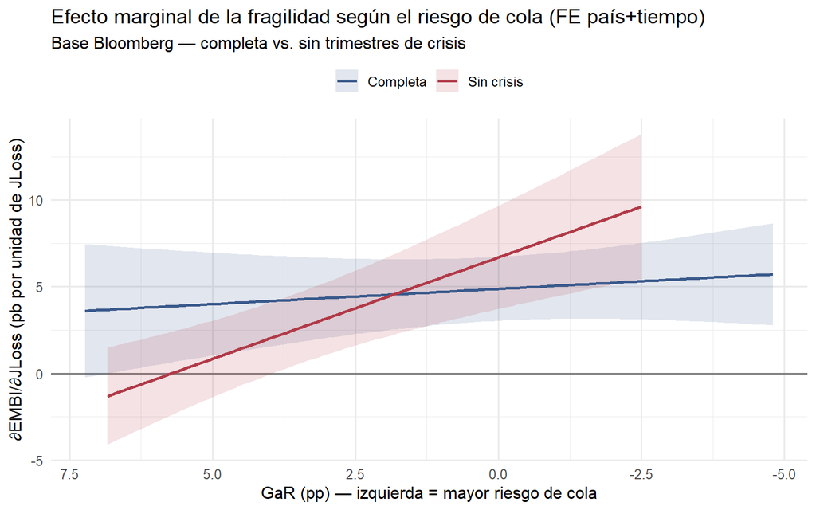

```r
marginal_df <- function(m, d) {
  V  <- DK(m); b <- coef(m)
  bJ <- b["JLoss_c"]; bI <- b["Int"]
  vJ <- V["JLoss_c","JLoss_c"]; vI <- V["Int","Int"]; cJI <- V["JLoss_c","Int"]
  mu <- mean(d$GaR_c, na.rm = TRUE)
  grid <- seq(quantile(d$GaR_c, .05, na.rm = TRUE), quantile(d$GaR_c, .95, na.rm = TRUE), length.out = 100)
  dev <- grid - mu
  me  <- bJ + bI * dev
  se  <- sqrt(vJ + dev^2 * vI + 2 * dev * cJI)
  data.frame(GaR_pp = grid + mean(d$GaR_pp, na.rm = TRUE) - mu, me = me, lo = me - 1.96*se, hi = me + 1.96*se)
}
mdf <- bind_rows(
  marginal_df(modelos_M4[["completa país+tiempo"]], dat) %>% mutate(muestra = "Completa"),
  marginal_df(modelos_M4[["sin crisis país+tiempo"]], centrar(subset(est, sin_crisis))) %>% mutate(muestra = "Sin crisis")
)
ggplot(mdf, aes(GaR_pp, me, color = muestra, fill = muestra)) +
  geom_hline(yintercept = 0, color = "grey50") +
  geom_ribbon(aes(ymin = lo, ymax = hi), alpha = .15, color = NA) +
  geom_line(linewidth = 1) +
  scale_x_reverse() +
  scale_color_manual(values = c("Completa" = "#3A5A8C", "Sin crisis" = "#b23a48")) +
  scale_fill_manual(values = c("Completa" = "#3A5A8C", "Sin crisis" = "#b23a48")) +
  labs(x = "GaR (pp) — izquierda = mayor riesgo de cola",
       y = "∂EMBI/∂JLoss (pb por unidad de JLoss)", color = NULL, fill = NULL,
       title = "Efecto marginal de la fragilidad según el riesgo de cola (FE país+tiempo)",
       subtitle = "Base Bloomberg — completa vs. sin trimestres de crisis") +
  theme_minimal(base_size = 12) + theme(legend.position = "top")
```

# 5 Diagnósticos y robustez de θ

```r
m_ref <- modelos_M4[["completa país+tiempo"]]
diag <- data.frame(
  test = c("Pesaran CD (dep. transversal)", "Wooldridge (autocorr.)"),
  estadistico = round(c(pcdtest(m_ref, test = "cd")$statistic, pbgtest(m_ref)$statistic), 3),
  p_valor = round(c(pcdtest(m_ref, test = "cd")$p.value, pbgtest(m_ref)$p.value), 4)
)
kable(diag, caption = "Diagnósticos del panel (sobre M4, FE país+tiempo, muestra completa)") %>%
  kable_styling(full_width = FALSE)
```

Diagnósticos del panel (sobre M4, FE país+tiempo, muestra completa)

|  | test | estadistico | p_valor |
| --- | --- | --- | --- |
| z | Pesaran CD (dep. transversal) | -2.835 | 0.0046 |
| chisq | Wooldridge (autocorr.) | 584.443 | 0.0000 |

```r
se_compare <- function(m) {
  variants <- list(
    "Driscoll-Kraay" = DK(m),
    "Cluster país"   = vcovHC(m, type = "HC1", cluster = "group"),
    "Cluster tiempo" = vcovHC(m, type = "HC1", cluster = "time"),
    "Arellano (HAC)" = vcovHC(m, method = "arellano", type = "HC1")
  )
  sapply(variants, function(v) {
    ct <- coeftest(m, vcov = v)["Int", ]
    c(coef = round(ct[1],3), se = round(ct[2],3), t = round(ct[3],2), p = round(ct[4],4))
  })
}
kable(t(se_compare(m_ref)), caption = "θ bajo distintas matrices de varianza (M4, FE país+tiempo, muestra completa)") %>%
  kable_styling(full_width = FALSE)
```

θ bajo distintas matrices de varianza (M4, FE país+tiempo, muestra completa)

|  | coef.Estimate | se.Std. Error | t.t value | p.Pr(>&#124;t&#124;) |
| --- | --- | --- | --- | --- |
| Driscoll-Kraay | -0.176 | 0.240 | -0.73 | 0.4653 |
| Cluster país | -0.176 | 0.305 | -0.58 | 0.5654 |
| Cluster tiempo | -0.176 | 0.159 | -1.10 | 0.2703 |
| Arellano (HAC) | -0.176 | 0.305 | -0.58 | 0.5654 |

```r
sub_dk <- function(mask, label) {
  d <- centrar(subset(est, mask))
  p <- pdata.frame(d, index = c("country", "tnum"))
  m <- plm(EMBI_bps ~ JLoss_c + GaR_c + Int, data = p, model = "within", effect = "twoways")
  cat("==", label, "==\n"); printCoefmat(coeftest(m, vcov = DK(m)))
  cat(sprintf("N = %d\n\n", nobs(m)))
  m
}
m_sin_covid <- sub_dk(est$sin_covid, "θ sin COVID (2020Q1-2021Q4 fuera), FE país+tiempo")
```

```
## == θ sin COVID (2020Q1-2021Q4 fuera), FE país+tiempo ==
##         Estimate Std. Error t value   Pr(>|t|)
## JLoss_c  4.12141    1.01108  4.0763 0.00005258 ***
## GaR_c   -6.93005    2.49997 -2.7721   0.005761 **
## Int     -0.80561    0.35108 -2.2947   0.022132 *
## ---
## Signif. codes:  0 '***' 0.001 '**' 0.01 '*' 0.05 '.' 0.1 ' ' 1
## N = 641
```

```r
m_sin_gfc   <- sub_dk(est$sin_gfc,   "θ sin GFC (2008Q4-2009Q4 fuera), FE país+tiempo")
```

```
## == θ sin GFC (2008Q4-2009Q4 fuera), FE país+tiempo ==
##         Estimate Std. Error t value  Pr(>|t|)
## JLoss_c  4.58705    1.05705  4.3395 0.0000168 ***
## GaR_c   -3.92732    2.73286 -1.4371    0.1512
## Int     -0.24438    0.26550 -0.9205    0.3577
## ---
## Signif. codes:  0 '***' 0.001 '**' 0.01 '*' 0.05 '.' 0.1 ' ' 1
## N = 690
```

```r
# Dinamico: EMBI rezagado
est_dyn <- est %>% arrange(country, tnum) %>% group_by(country) %>%
  mutate(EMBI_lag = lag(EMBI_bps)) %>% ungroup() %>% as.data.frame()
d_dyn <- centrar(est_dyn)
p_dyn <- pdata.frame(d_dyn, index = c("country", "tnum"))
m_dyn <- plm(EMBI_bps ~ EMBI_lag + JLoss_c + GaR_c + Int, data = p_dyn, model = "within", effect = "twoways")
cat("== θ dinámico (EMBI rezagado), FE país+tiempo ==\n"); printCoefmat(coeftest(m_dyn, vcov = DK(m_dyn)))
```

```
## == θ dinámico (EMBI rezagado), FE país+tiempo ==
```

```
##           Estimate Std. Error t value              Pr(>|t|)
## EMBI_lag  0.906757   0.026784 33.8542 < 0.00000000000000022 ***
## JLoss_c   0.902438   0.307039  2.9392              0.003417 **
## GaR_c    -0.104486   0.557033 -0.1876              0.851272
## Int      -0.125197   0.064793 -1.9323              0.053795 .
## ---
## Signif. codes:  0 '***' 0.001 '**' 0.01 '*' 0.05 '.' 0.1 ' ' 1
```

# 6 Heterogeneidad: el núcleo de economías emergentes de financiamiento externo

```r
fit_ctrl <- function(d, extra = character(0)) {
  dd <- d[complete.cases(d[, c("EMBI_bps","JLoss","GaR_pp", CTRLS)]), ]
  dd <- centrar(dd)
  pdd <- pdata.frame(dd, index = c("country", "tnum"))
  f <- as.formula(paste("EMBI_bps ~ JLoss_c + GaR_c + Int +", paste(CTRLS, collapse = " + ")))
  m <- plm(f, data = pdd, model = "within", effect = "twoways")
  list(model = m, N = nobs(m), G = length(unique(dd$country)))
}

r_completa_ctrl <- fit_ctrl(est)
r_nucleo        <- fit_ctrl(subset(est, !(country %in% NUCLEO_EXCL)))
r_sin_crisis_ctrl <- fit_ctrl(subset(est, sin_crisis))
r_nucleo_sin_crisis <- fit_ctrl(subset(est, sin_crisis & !(country %in% NUCLEO_EXCL)))

get_theta <- function(r, label) {
  ct <- coeftest(r$model, vcov = DK(r$model))
  data.frame(spec = label, theta = ct["Int","Estimate"], se = ct["Int","Std. Error"],
             t = ct["Int","t value"], p = ct["Int","Pr(>|t|)"], N = r$N, paises = r$G)
}
hetero <- bind_rows(
  get_theta(r_completa_ctrl,      "M2+controles, completa (todos los países)"),
  get_theta(r_nucleo,             "M2+controles, núcleo (11 EM, sin Polonia/India)"),
  get_theta(r_sin_crisis_ctrl,    "M2+controles, sin crisis (todos los países)"),
  get_theta(r_nucleo_sin_crisis,  "M2+controles, núcleo Y sin crisis")
) %>% mutate(across(c(theta, se, t, p), ~round(., 4)))

kable(hetero, caption = "θ bajo la especificación M2+controles — dimensión transversal, temporal y combinada") %>%
  kable_styling(full_width = FALSE) %>%
  row_spec(4, bold = TRUE, background = "#fdf1e8")
```

θ bajo la especificación M2+controles — dimensión transversal, temporal y combinada

| spec | theta | se | t | p | N | paises |
| --- | --- | --- | --- | --- | --- | --- |
| M2+controles, completa (todos los países) | -0.1877 | 0.1455 | -1.2900 | 0.1976 | 614 | 13 |
| M2+controles, núcleo (11 EM, sin Polonia/India) | -0.4922 | 0.1903 | -2.5859 | 0.0101 | 479 | 11 |
| M2+controles, sin crisis (todos los países) | -0.6809 | 0.3137 | -2.1706 | 0.0305 | 519 | 13 |
| M2+controles, núcleo Y sin crisis | -0.9342 | 0.2890 | -3.2330 | 0.0014 | 405 | 11 |

**Las dos dimensiones apuntan al mismo mecanismo.** Combinando ambas condicionalidades —núcleo de EM de financiamiento externo, excluyendo trimestres de crisis— el coeficiente llega a su magnitud e inferencia más nítidas: la interacción se identifica cuando el mercado espera que el pasivo contingente bancario recaiga sobre un soberano **no respaldado**, cuya deuda fija al margen un inversor de cartera extranjero sensible al riesgo — ausente donde la deuda está en manos de inversores domésticos de largo horizonte (Polonia, India) y donde un respaldo oficial desacopla la transmisión (líneas swap de la Fed, FMI, QE doméstico en GFC/COVID).

# 7 Síntesis: triangulación de θ

```r
get_theta_dk <- function(m, label, N = NULL) {
  if (is.null(m)) return(NULL)
  ct <- coeftest(m, vcov = DK(m))
  data.frame(modelo = label, theta = ct["Int","Estimate"], se = ct["Int","Std. Error"],
             p = ct["Int","Pr(>|t|)"], N = if (is.null(N)) nobs(m) else N)
}
synth <- bind_rows(
  get_theta_dk(modelos_M4[["completa país+tiempo"]], "M4, completa (FE país+tiempo)"),
  get_theta_dk(modelos_M4[["sin crisis país+tiempo"]], "M4, sin crisis (FE país+tiempo)"),
  get_theta_dk(m_sin_covid, "Sin COVID solo"),
  get_theta_dk(m_sin_gfc,   "Sin GFC solo"),
  get_theta_dk(m_dyn,       "Dinámico (EMBI rezagado)"),
  get_theta(r_nucleo, "M2+controles, núcleo (11 EM)") %>% select(modelo = spec, theta, se, p, N),
  get_theta(r_nucleo_sin_crisis, "M2+controles, núcleo y sin crisis") %>% select(modelo = spec, theta, se, p, N)
) %>% mutate(lo = theta - 1.96*se, hi = theta + 1.96*se)

kable(synth %>% mutate(across(c(theta, se, p), ~round(., 4))),
      caption = "Coeficiente θ de JLoss × GaR a través de la batería y la robustez") %>%
  kable_styling(full_width = FALSE)
```

Coeficiente θ de JLoss × GaR a través de la batería y la robustez

| modelo | theta | se | p | N | lo | hi |
| --- | --- | --- | --- | --- | --- | --- |
| M4, completa (FE país+tiempo) | -0.1756 | 0.2404 | 0.4653 | 721 | -0.6466855 | 0.2955063 |
| M4, sin crisis (FE país+tiempo) | -1.1713 | 0.3027 | 0.0001 | 610 | -1.7646005 | -0.5779221 |
| Sin COVID solo | -0.8056 | 0.3511 | 0.0221 | 641 | -1.4937198 | -0.1174935 |
| Sin GFC solo | -0.2444 | 0.2655 | 0.3577 | 690 | -0.7647545 | 0.2759968 |
| Dinámico (EMBI rezagado) | -0.1252 | 0.0648 | 0.0538 | 708 | -0.2521911 | 0.0017973 |
| M2+controles, núcleo (11 EM) | -0.4922 | 0.1903 | 0.0101 | 479 | -0.8652216 | -0.1191212 |
| M2+controles, núcleo y sin crisis | -0.9342 | 0.2890 | 0.0014 | 405 | -1.5005119 | -0.3678270 |

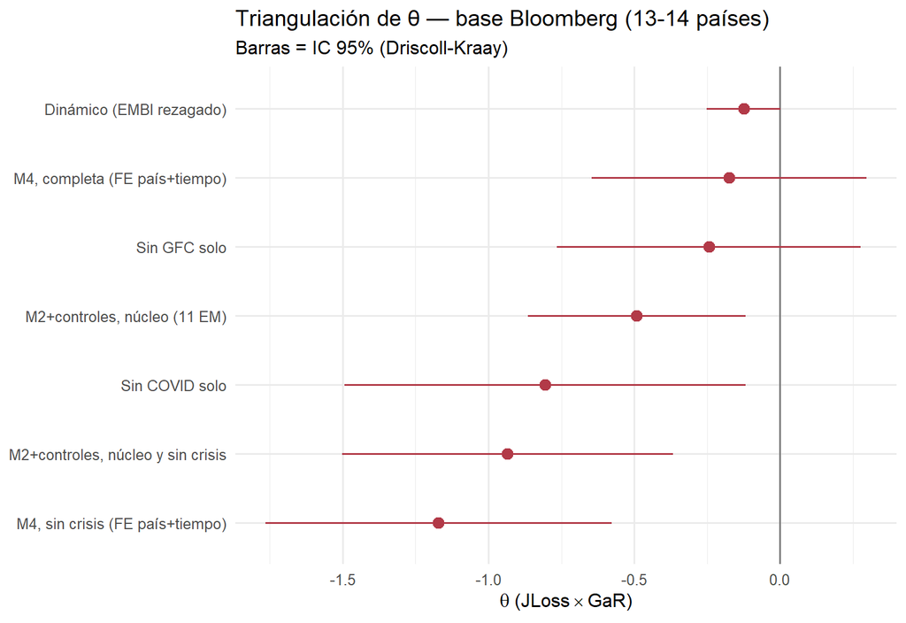

```r
ggplot(synth, aes(x = theta, y = reorder(modelo, theta))) +
  geom_vline(xintercept = 0, color = "grey50") +
  geom_pointrange(aes(xmin = lo, xmax = hi), color = "#b23a48") +
  labs(x = expression(theta ~ "(JLoss" %*% "GaR)"), y = NULL,
       title = "Triangulación de θ — base Bloomberg (13-14 países)",
       subtitle = "Barras = IC 95% (Driscoll-Kraay)") +
  theme_minimal(base_size = 12)
```

# 8 Notas

- **Base:** `bbg/Panel_bloomberg.csv` (panel único ancla en Bloomberg; EMBI Global Diversified, JLoss, GaR). Esta es la base **final y canónica** de la tesis — reemplaza a la anterior `Panel_extended_15paises.csv` (regulatoria, 11 países, sin EMBI Global Diversified), que queda superada.
- **Esqueleto:** la batería de 24 especificaciones (Tabla 2.3 de la tesis) es la fuente de verdad; este documento la reproduce íntegra y agrega diagnósticos y robustez alrededor de la especificación de referencia (M4, FE país+tiempo).
- **Fuente canónica de cifras:** `bbg/NUMEROS_CANONICOS_BBG.md` y `bbg/bateria_bbg.csv` — si un número de este documento difiere, esos archivos son la referencia.
- **Panel desbalanceado:** las ventanas temporales difieren por país; toda la inferencia usa errores de Driscoll-Kraay (`plm::vcovSCC`).